# micro-RNA Vesicles

## Импортируем данные

```
✓ Configuration loaded successfully
✓ Configuration loaded successfully

============================================================
LOADING AND PROCESSING DATA
============================================================

Loading phenotable data...
   File: /Users/dariakilina/GitHub/ncRNA_pipeline/Vesicles_CABG/data/phenotableV.tsv
   ✓ Loaded 12 samples
   ✓ Groups: after_150, after_16, before_150, before_16

 Loading counts data...
   File: /Users/dariakilina/GitHub/ncRNA_pipeline/data/raw/miR.Counts.csv
   ✓ Loaded 2731 features × 49 samples

 Cleaning sample names...
   ✓ No cleaning needed

🔗 Matching samples between counts and phenotable...
   Counts:    49 samples
   phenotable: 12 samples
   Common:    12 samples
 37 counts samples not in phenotable
   ✓ Sample order verified

 Filtering low-expressed features...
   Smallest group size: 3 samples
   Threshold: >= 10 counts in >= 3 samples
   ✓ Kept 338 / 2731 features (12.4%)
   ✓ Removed 2393 low-expressed features

============================================================
✅ DATA PROCESSING COMPLETE
============================================================

Final dataset: 338 features × 12 samples
Groups: after_150, after_16, before_150, before_16
Samples per group:

 after_150   after_16 before_150  before_16
         3          3          3          3

📋 Loading sample annotation...
   File: /Users/dariakilina/GitHub/ncRNA_pipeline/data/raw/annotation.report.csv
   ✓ Loaded 49 samples × 15 columns
   ✓ Retained 9 columns after filtering

🔗 Matching annotation with phenotype...
   Annotation samples: 49
   Phenotype samples:  12
   Common samples:     12
   ✓ Annotation successfully aligned
```

**Диаграмма Венна: микро РНК (>150 каунтов)**

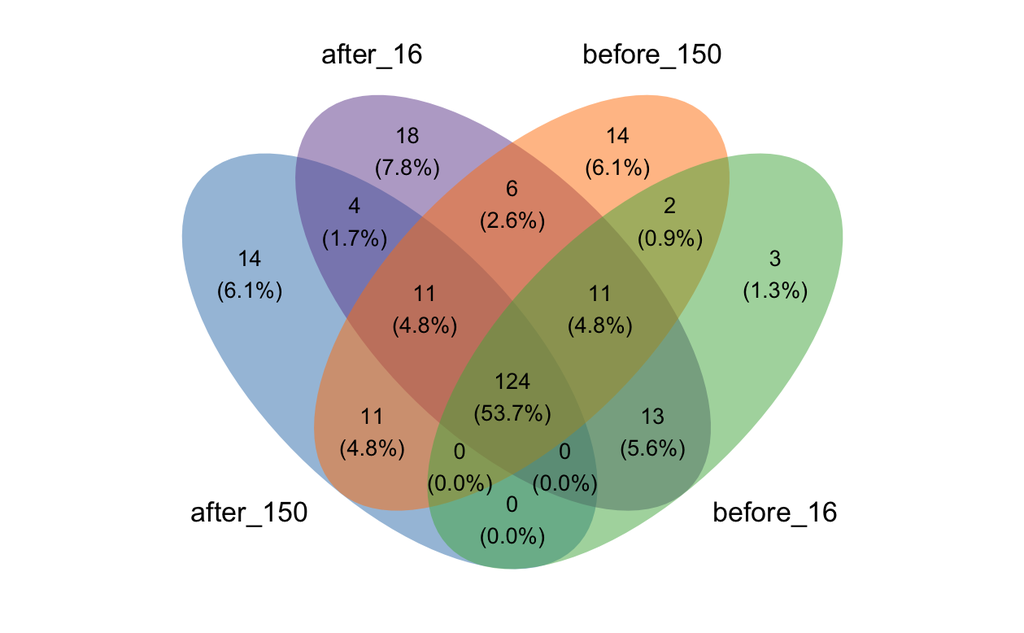

**Уникальные микроРНК для каждой группы**

```
$after_150
 [1] "hsa-let-7f-2-3p" "hsa-miR-101-5p"  "hsa-miR-136-5p"  "hsa-miR-195-3p"  "hsa-miR-196b-5p" "hsa-miR-208b-3p" "hsa-miR-3143"
 [8] "hsa-miR-323b-3p" "hsa-miR-3605-5p" "hsa-miR-452-5p"  "hsa-miR-499a-5p" "hsa-miR-548e-5p" "hsa-miR-548o-3p" "hsa-miR-651-5p"

$after_16
 [1] "hsa-miR-1306-5p"       "hsa-miR-146b-3p"       "hsa-miR-181d-5p"       "hsa-miR-185-3p"        "hsa-miR-199b-5p"
 [6] "hsa-miR-27a-5p"        "hsa-miR-27b-5p"        "hsa-miR-330-5p"        "hsa-miR-340-3p"        "hsa-miR-431-5p"
[11] "hsa-miR-432-5p"        "hsa-miR-4662a-5p"      "hsa-miR-4677-3p"       "hsa-miR-487b-3p"       "hsa-miR-548av-5p/548k"
[16] "hsa-miR-625-3p"        "hsa-miR-6852-5p"       "hsa-miR-874-3p"

$before_150
 [1] "hsa-miR-122-5p"    "hsa-miR-125b-2-3p" "hsa-miR-145-3p"    "hsa-miR-193b-5p"   "hsa-miR-197-3p"    "hsa-miR-1976"
 [7] "hsa-miR-205-5p"    "hsa-miR-22-5p"     "hsa-miR-424-5p"    "hsa-miR-483-5p"    "hsa-miR-501-3p"    "hsa-miR-550a-3p"
[13] "hsa-miR-6511a-3p"  "hsa-miR-873-5p"

$before_16
[1] "hsa-miR-195-5p" "hsa-miR-29b-3p" "hsa-miR-671-3p"
```

**Распределение количества ридов различных типов РНК по образцам**

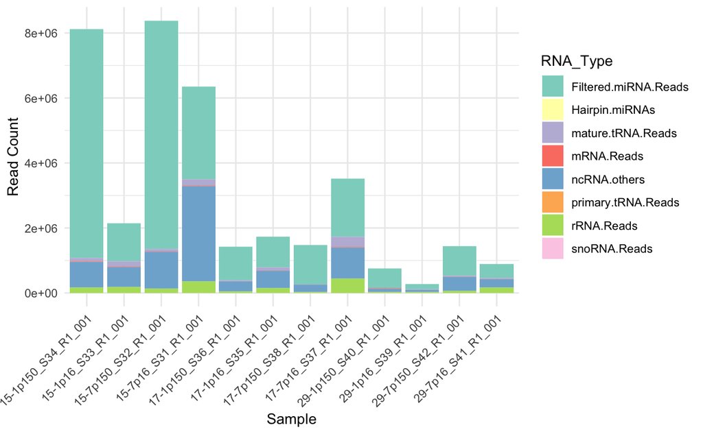

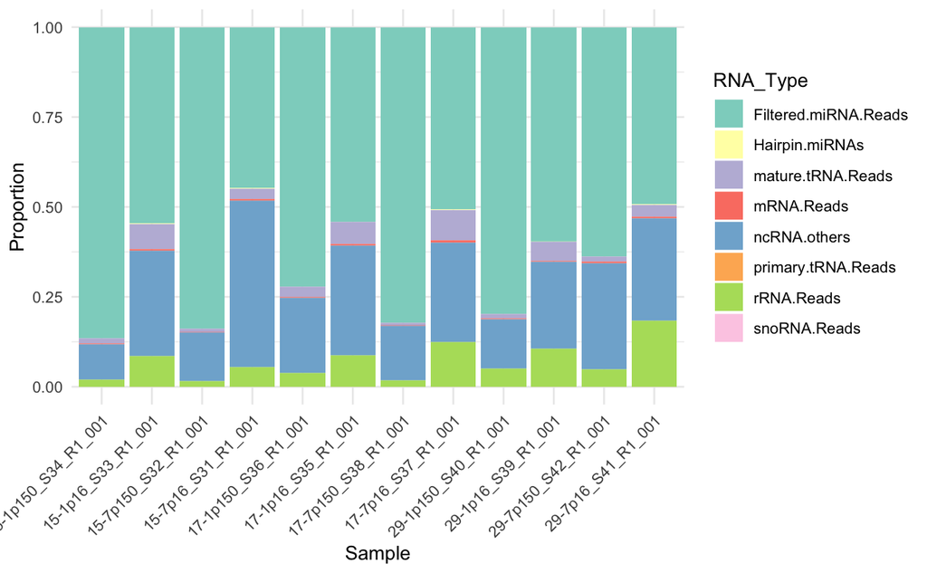

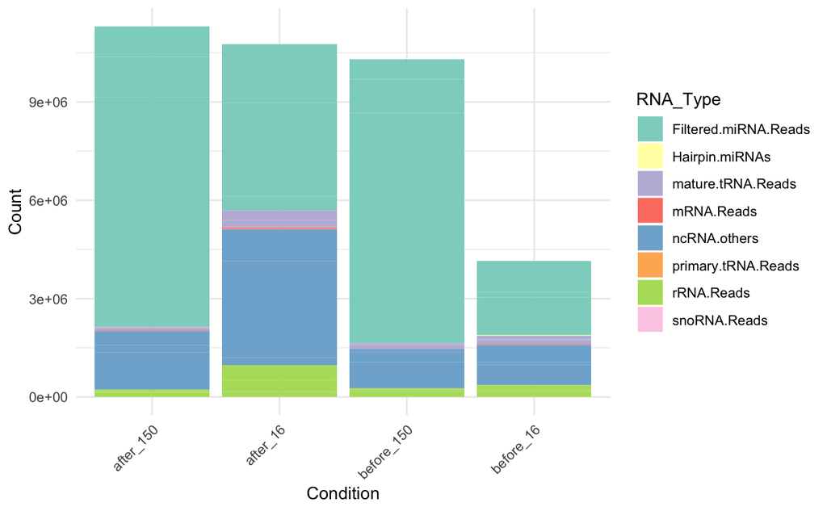

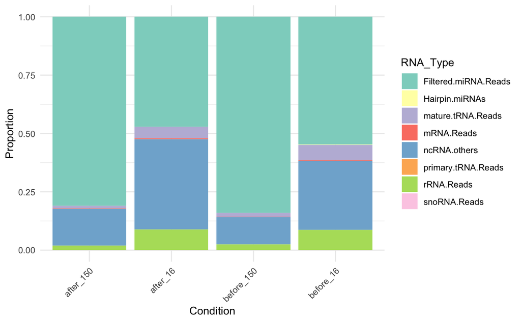

```
   (Intercept) type16 timeafter patient17 patient29 type16:timeafter
10           1      0         1         0         0                0
2            1      1         0         0         0                0
7            1      1         1         0         1                1
8            1      1         1         0         0                1
1            1      1         0         0         1                0
12           1      0         1         1         0                0
5            1      0         0         0         0                0
11           1      0         1         0         1                0
6            1      0         0         1         0                0
9            1      1         1         1         0                1
3            1      1         0         1         0                0
4            1      0         0         0         1                0
attr(,"assign")
[1] 0 1 2 3 3 4
attr(,"contrasts")
attr(,"contrasts")$type
[1] "contr.treatment"

attr(,"contrasts")$time
[1] "contr.treatment"

attr(,"contrasts")$patient
[1] "contr.treatment"
```

```
class: DESeqDataSet
dim: 338 12
metadata(1): version
assays(1): counts
rownames(338): hsa-let-7a-3p hsa-let-7a-5p/7c-5p ... hsa-miR-99a-5p hsa-miR-99b-5p
rowData names(0):
colnames(12): 15-7p150_S32_R1_001 15-1p16_S33_R1_001 ... 17-1p16_S35_R1_001 29-1p150_S40_R1_001
colData names(5): sample time type patient condition
```

**Run Differential Expression Analysis for all dataset**

```
class: DESeqDataSet
dim: 338 12
metadata(1): version
assays(4): counts mu H cooks
rownames(338): hsa-let-7a-3p hsa-let-7a-5p/7c-5p ... hsa-miR-99a-5p hsa-miR-99b-5p
rowData names(38): baseMean baseVar ... deviance maxCooks
colnames(12): 15-7p150_S32_R1_001 15-1p16_S33_R1_001 ... 17-1p16_S35_R1_001 29-1p150_S40_R1_001
colData names(6): sample time ... condition sizeFactor
```

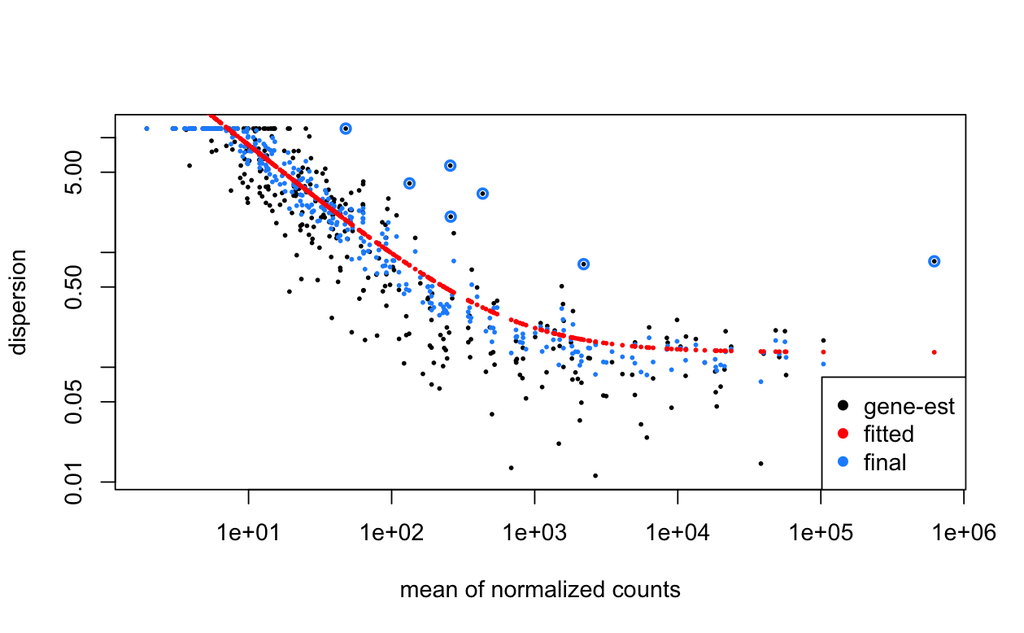

```
15-7p150_S32_R1_001  15-1p16_S33_R1_001  29-7p16_S41_R1_001  15-7p16_S31_R1_001  29-1p16_S39_R1_001 17-7p150_S38_R1_001 15-1p150_S34_R1_001
            7022896             1170126              442792             2845995              163996             1204090             7020403
29-7p150_S42_R1_001 17-1p150_S36_R1_001  17-7p16_S37_R1_001  17-1p16_S35_R1_001 29-1p150_S40_R1_001
             922182             1028671             1782348              939396              604233
[1] 25147128
```

**rlog трансформация**

```
Samples: 12
Genes: 338
Using rlog transformation
```

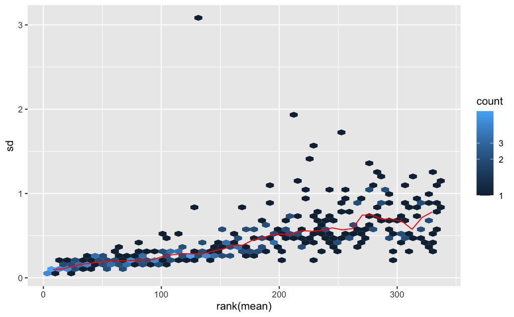

```
$transformed
class: DESeqTransform
dim: 338 12
metadata(1): version
assays(1): ''
rownames(338): hsa-let-7a-3p hsa-let-7a-5p/7c-5p ... hsa-miR-99a-5p hsa-miR-99b-5p
rowData names(39): baseMean baseVar ... maxCooks rlogIntercept
colnames(12): 15-7p150_S32_R1_001 15-1p16_S33_R1_001 ... 17-1p16_S35_R1_001 29-1p150_S40_R1_001
colData names(6): sample time ... condition sizeFactor

$method
[1] "rlog"
```

**PCA plot**

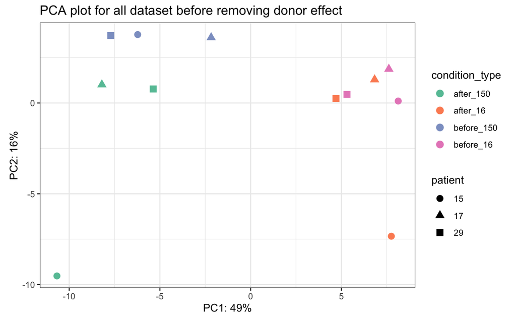

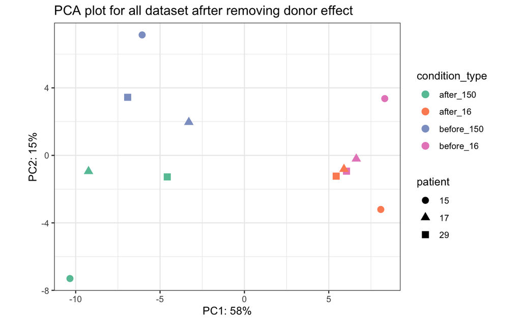

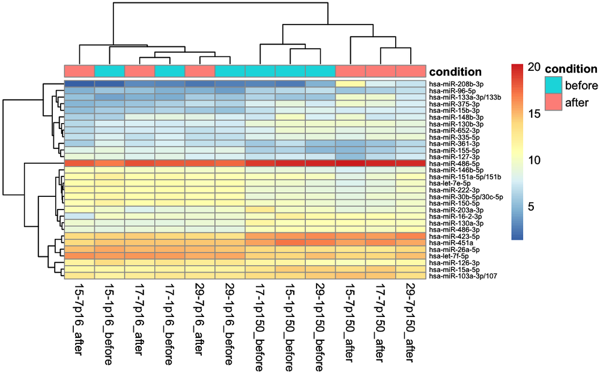

**Plot of the distance between samples heatmap** Расчет расстояний между образцами • Обычно используется евклидово расстояние (по умолчанию в DESeq2). • Оно вычисляется по нормализованным данным экспрессии (rlog() или vst()). • Чем меньше расстояние — тем более похожи образцы.

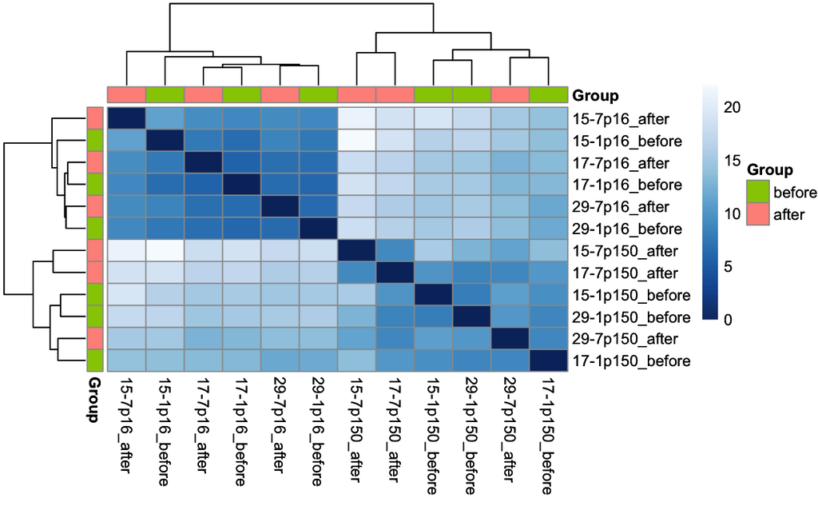

## Только везикулы типа 150

|  | time | type | patient | condition |
| --- | --- | --- | --- | --- |
| 15-7p150_S32_R1_001 | after | 150 | 15 | after_150 |
| 17-7p150_S38_R1_001 | after | 150 | 17 | after_150 |
| 15-1p150_S34_R1_001 | before | 150 | 15 | before_150 |
| 29-7p150_S42_R1_001 | after | 150 | 29 | after_150 |
| 17-1p150_S36_R1_001 | before | 150 | 17 | before_150 |
| 29-1p150_S40_R1_001 | before | 150 | 29 | before_150 |

|  | 15-7p150_S32_R1_001 | 17-7p150_S38_R1_001 | 15-1p150_S34_R1_001 | 29-7p150_S42_R1_001 | 17-1p150_S36_R1_001 | 29-1p150_S40_R1_001 |
| --- | --- | --- | --- | --- | --- | --- |
| hsa-let-7a-3p | 15 | 78 | 237 | 0 | 86 | 19 |
| hsa-let-7a-5p/7c-5p | 18202 | 6398 | 30241 | 6154 | 10705 | 4289 |
| hsa-let-7b-3p | 0 | 230 | 519 | 7 | 98 | 17 |
| hsa-let-7b-5p | 1948 | 1351 | 4884 | 964 | 1664 | 663 |
| hsa-let-7d-3p | 2276 | 2964 | 6414 | 830 | 2926 | 425 |
| hsa-let-7d-5p | 1162 | 401 | 2177 | 354 | 635 | 319 |

```
   Min. 1st Qu.  Median    Mean 3rd Qu.    Max.
 604233  948804 1116380 2967079 5566325 7022896
```

```
                    patient15 patient17 patient29 timeafter
15-7p150_S32_R1_001         1         0         0         1
17-7p150_S38_R1_001         0         1         0         1
15-1p150_S34_R1_001         1         0         0         0
29-7p150_S42_R1_001         0         0         1         1
17-1p150_S36_R1_001         0         1         0         0
29-1p150_S40_R1_001         0         0         1         0
attr(,"assign")
[1] 1 1 1 2
attr(,"contrasts")
attr(,"contrasts")$patient
[1] "contr.treatment"

attr(,"contrasts")$time
[1] "contr.treatment"
```

**Создаем DESeqDataSet из матрицы каунтов**

```
class: DESeqDataSet
dim: 338 6
metadata(1): version
assays(1): counts
rownames(338): hsa-let-7a-3p hsa-let-7a-5p/7c-5p ... hsa-miR-99a-5p hsa-miR-99b-5p
rowData names(0):
colnames(6): 15-7p150_S32_R1_001 17-7p150_S38_R1_001 ... 17-1p150_S36_R1_001 29-1p150_S40_R1_001
colData names(4): time type patient condition
```

```
[1] 338   6
[1] 278   6
```

**Run Differential Expression Analysis for 150 type**

```
log2 fold change (MLE): time after vs before
Wald test p-value: timeafter
DataFrame with 278 rows and 6 columns
                      baseMean log2FoldChange     lfcSE      stat    pvalue      padj
                     <numeric>      <numeric> <numeric> <numeric> <numeric> <numeric>
hsa-let-7a-3p          54.2247      -3.377324  1.559629 -2.165466  0.030352  0.345235
hsa-let-7a-5p/7c-5p 10304.9760      -0.412335  0.399046 -1.033301  0.301463  0.911056
hsa-let-7b-3p         100.3366      -2.428330  1.492219 -1.627328  0.103667  0.709127
hsa-let-7b-5p        1625.3846      -0.455998  0.464781 -0.981102  0.326542  0.911056
hsa-let-7d-3p        2085.8803      -0.259569  0.479957 -0.540818  0.588633  0.963336
...                        ...            ...       ...       ...       ...       ...
hsa-miR-95-5p          9.78937       0.335046  3.159740  0.106036  0.915554        NA
hsa-miR-96-5p        190.83554      -0.681199  0.817408 -0.833365  0.404639  0.963336
hsa-miR-98-5p        311.06970       0.185659  0.700535  0.265024  0.790991  0.972186
hsa-miR-99a-5p        58.89546      -1.908296  1.477048 -1.291966  0.196369  0.911056
hsa-miR-99b-5p       378.78170      -0.240000  0.695690 -0.344981  0.730109  0.963336
```

**MA plot**

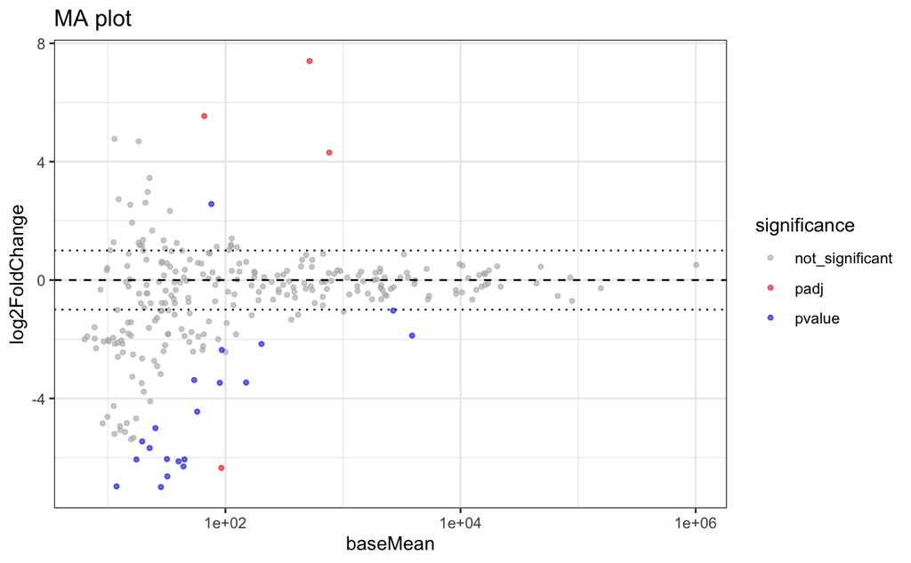

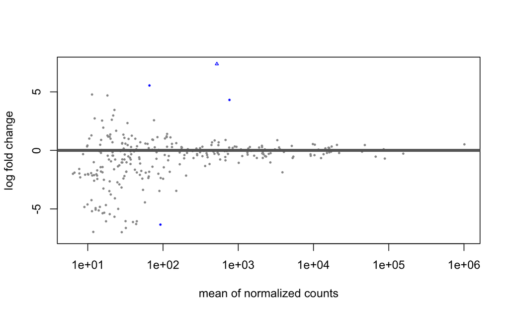

**Значимые результаты**

```
out of 278 with nonzero total read count
adjusted p-value < 0.05
LFC > 0 (up)       : 3, 1.1%
LFC < 0 (down)     : 1, 0.36%
outliers [1]       : 0, 0%
low counts [2]     : 0, 0%
(mean count < 6)
[1] see 'cooksCutoff' argument of ?results
[2] see 'independentFiltering' argument of ?results
```

|  | baseMean | log2FoldChange | lfcSE | stat | pvalue | padj |
| --- | --- | --- | --- | --- | --- | --- |
| hsa-miR-133a-3p/133b | 763.80832 | 4.309391 | 0.6276306 | 6.866125 | 6.596916e-12 | 6.860793e-10 |
| hsa-miR-208b-3p | 519.51567 | 7.401276 | 1.0452860 | 7.080622 | 1.435086e-12 | 2.984980e-10 |
| hsa-miR-328-3p | 92.36228 | -6.345308 | 1.6316943 | -3.888785 | 1.007475e-04 | 6.985159e-03 |
| hsa-miR-499a-5p | 66.02150 | 5.543583 | 1.4810184 | 3.743089 | 1.817719e-04 | 9.452141e-03 |

Visualisation for the first gene

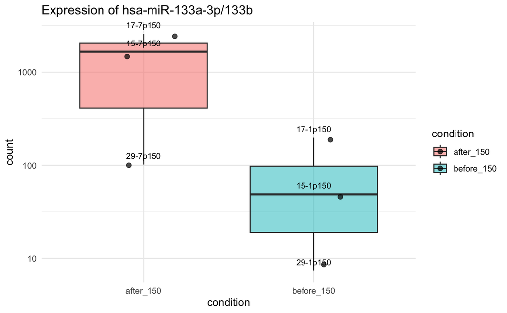

**Volcano plot**

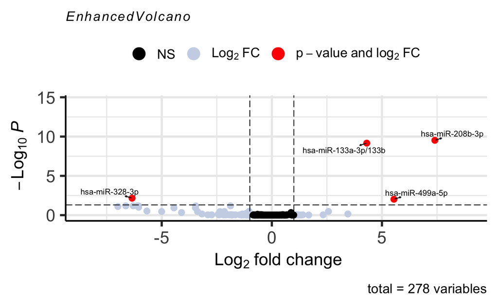

**rlog трансформация** • Черные точки – стандартное отклонение отдельных генов. • Красная линия – сглаженный тренд зависимости SD от среднего значения экспрессии. • Если красная линия наклонена вверх → стандартное отклонение растёт с увеличением среднего (плохая нормализация). • Если красная линия примерно горизонтальна → нормализация сработала хорошо.

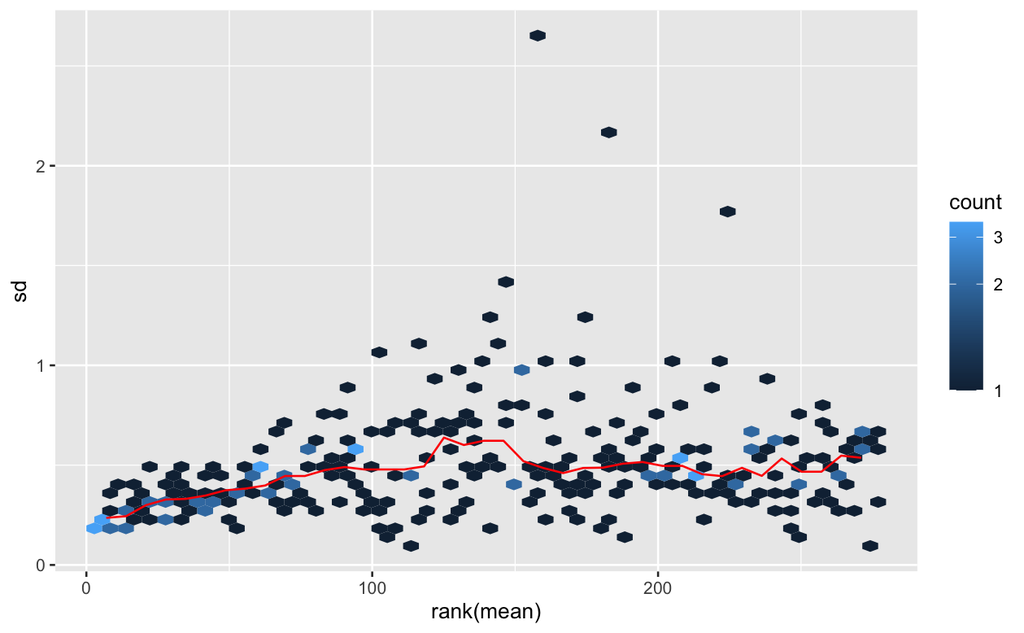

**PCA plot** PCA – это метод снижения размерности, который показывает различия между образцами. Строится на основе различий в экспрессии по всем генам, даже если они не являются значимо дифференциально экспрессированными. • Оно не накладывает статистических порогов вроде padj < 0.05 или |log2FoldChange| > 1, а просто ищет наибольшие источники вариабельности среди всех измерений. • Поэтому даже небольшие изменения экспрессии могут формировать кластеры и различать группы в PCA, если эти изменения систематичны между образцами.

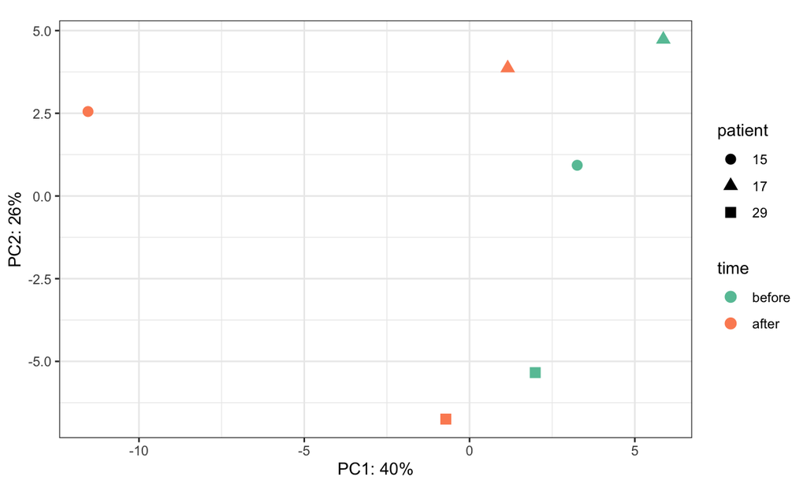

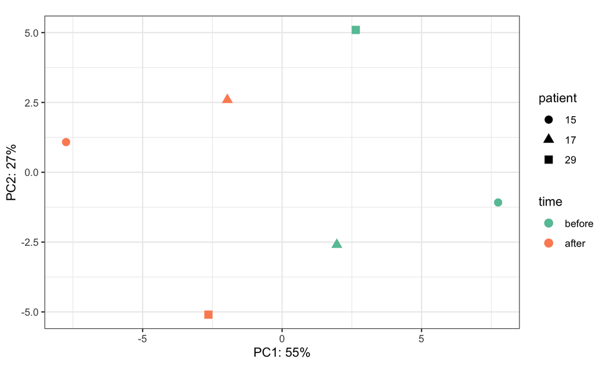

**Plot a heatmap of diff expressed genes**

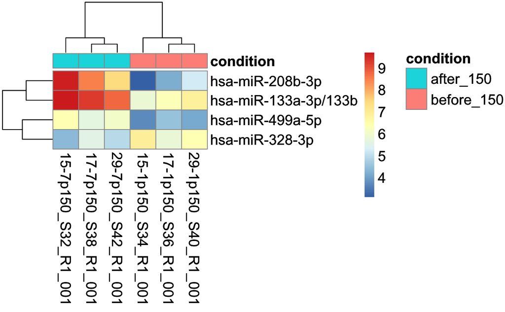

**Plot of the distance between samples heatmap** Расчет расстояний между образцами • Обычно используется евклидово расстояние (по умолчанию в DESeq2). • Оно вычисляется по нормализованным данным экспрессии (rlog() или vst()). • Чем меньше расстояние — тем более похожи образцы.

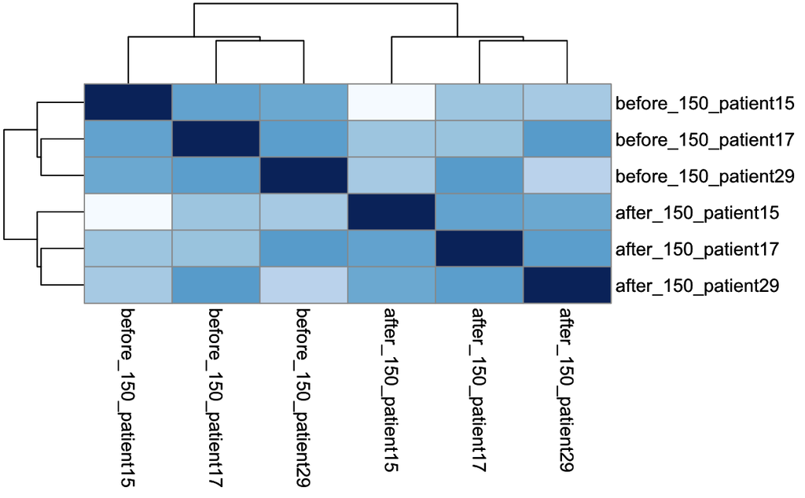

### Анализ обогащения для везикул типа 150

```
Searching mirecords ...
Searching mirtarbase ...
Searching tarbase ...
Searching mirecords ...
Searching mirtarbase ...
Searching tarbase ...
```

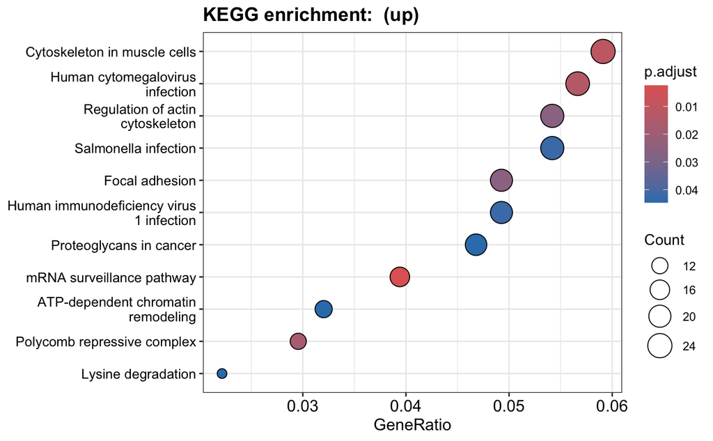

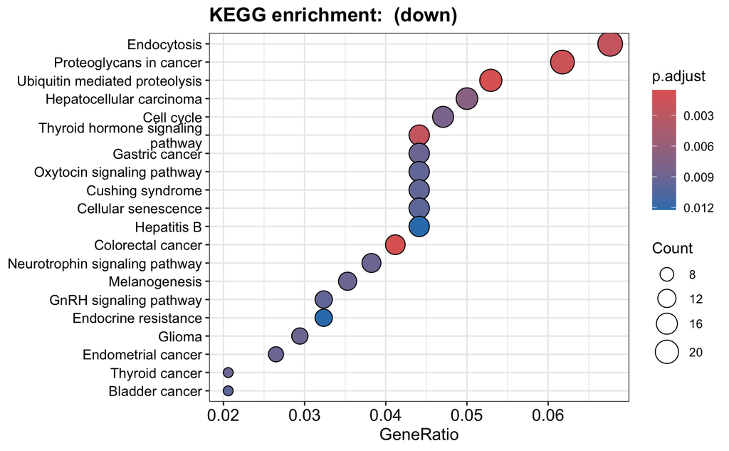

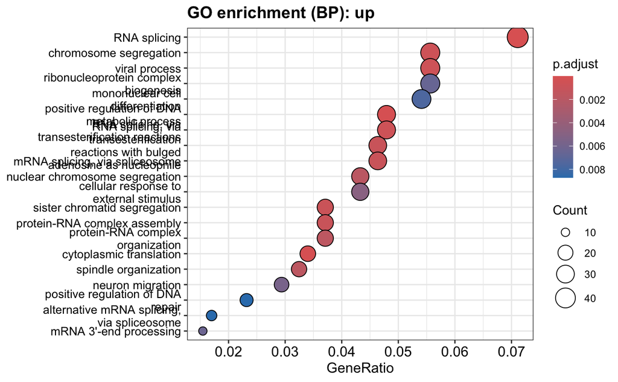

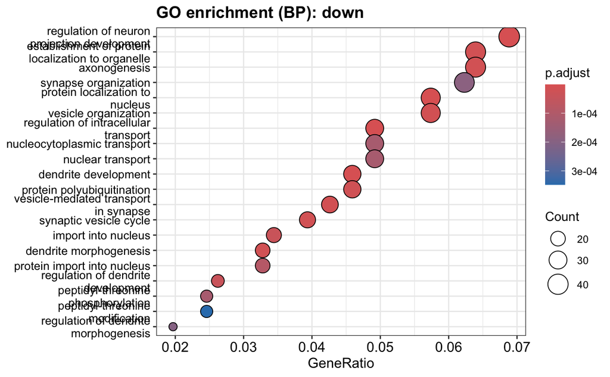

### Только везикулы типа 16

|  | sample | time | type | patient | condition |
| --- | --- | --- | --- | --- | --- |
| 15-1p16_S33_R1_001 | 15-1p16_S33_R1_001 | before | 16 | 15 | before_16 |
| 29-7p16_S41_R1_001 | 29-7p16_S41_R1_001 | after | 16 | 29 | after_16 |
| 15-7p16_S31_R1_001 | 15-7p16_S31_R1_001 | after | 16 | 15 | after_16 |
| 29-1p16_S39_R1_001 | 29-1p16_S39_R1_001 | before | 16 | 29 | before_16 |
| 17-7p16_S37_R1_001 | 17-7p16_S37_R1_001 | after | 16 | 17 | after_16 |
| 17-1p16_S35_R1_001 | 17-1p16_S35_R1_001 | before | 16 | 17 | before_16 |

|  | 15-1p16_S33_R1_001 | 29-7p16_S41_R1_001 | 15-7p16_S31_R1_001 | 29-1p16_S39_R1_001 | 17-7p16_S37_R1_001 | 17-1p16_S35_R1_001 |
| --- | --- | --- | --- | --- | --- | --- |
| hsa-let-7a-3p | 72 | 0 | 176 | 8 | 56 | 62 |
| hsa-let-7a-5p/7c-5p | 44111 | 8992 | 83965 | 4567 | 57272 | 31702 |
| hsa-let-7b-3p | 0 | 0 | 0 | 0 | 67 | 115 |
| hsa-let-7b-5p | 3690 | 1040 | 1940 | 662 | 4527 | 2621 |
| hsa-let-7d-3p | 1472 | 331 | 803 | 108 | 1533 | 733 |
| hsa-let-7d-5p | 2503 | 655 | 4221 | 307 | 3850 | 1712 |

**Создаем DESeqDataSet из матрицы каунтов**

```
class: DESeqDataSet
dim: 338 6
metadata(1): version
assays(1): counts
rownames(338): hsa-let-7a-3p hsa-let-7a-5p/7c-5p ... hsa-miR-99a-5p hsa-miR-99b-5p
rowData names(0):
colnames(6): 15-1p16_S33_R1_001 29-7p16_S41_R1_001 ... 17-7p16_S37_R1_001 17-1p16_S35_R1_001
colData names(5): sample time type patient condition
```

**Фильтрация**

```
[1] 338   6
[1] 243   6
```

[output not shown]

```
log2 fold change (MLE): time after vs before
Wald test p-value: timeafter
DataFrame with 243 rows and 6 columns
                      baseMean log2FoldChange     lfcSE       stat    pvalue      padj
                     <numeric>      <numeric> <numeric>  <numeric> <numeric> <numeric>
hsa-let-7a-3p          38.8637     -1.7647365  1.664290  -1.060354 0.2889835  0.888899
hsa-let-7a-5p/7c-5p 25817.3252     -0.1809210  0.227597  -0.794918 0.4266611  0.915599
hsa-let-7b-5p        2168.2826     -0.9269173  0.361298  -2.565520 0.0103021  0.467367
hsa-let-7d-3p         637.8371     -0.4835183  0.505840  -0.955871 0.3391373  0.905608
hsa-let-7d-5p        1554.0597     -0.0939003  0.323695  -0.290089 0.7717483  0.956173
...                        ...            ...       ...        ...       ...       ...
hsa-miR-942-5p         51.6123       0.107529  1.232012  0.0872794 0.9304494  0.993156
hsa-miR-96-5p          14.3672       4.235871  2.898613  1.4613439 0.1439211  0.862524
hsa-miR-98-5p         602.6328       0.259229  0.451201  0.5745319 0.5656079  0.915599
hsa-miR-99a-5p         76.3042      -0.103857  1.036402 -0.1002095 0.9201780  0.993156
hsa-miR-99b-5p        634.8668      -1.179768  0.585797 -2.0139543 0.0440143  0.560084
```

**MA plot**

Фильтрация точек с низким средним экспрессированием (по baseMean). • Обычно отсекаются baseMean < 1. 2. Определение значимых генов (синие точки): • Используется критерий padj < 0.1 по умолчанию, а не < 0.05!

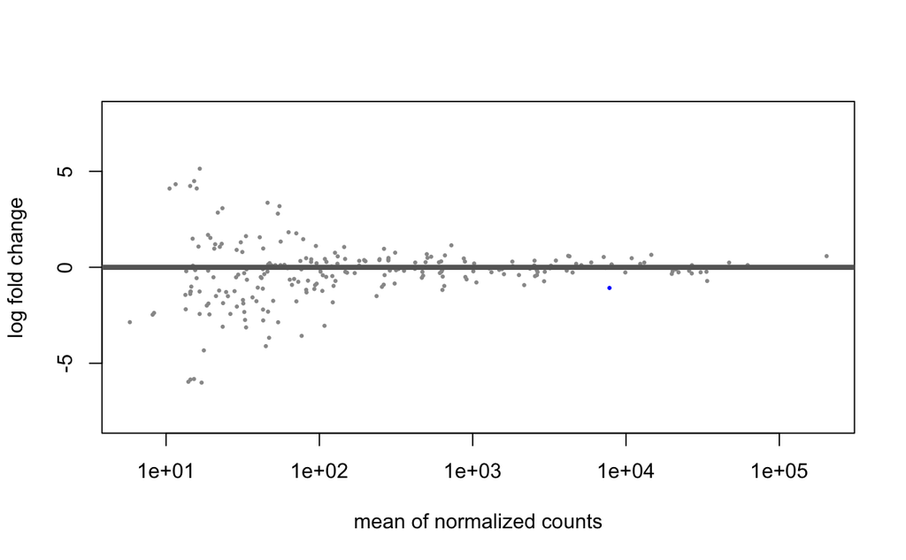

**Кастомный MA plot по p-value**

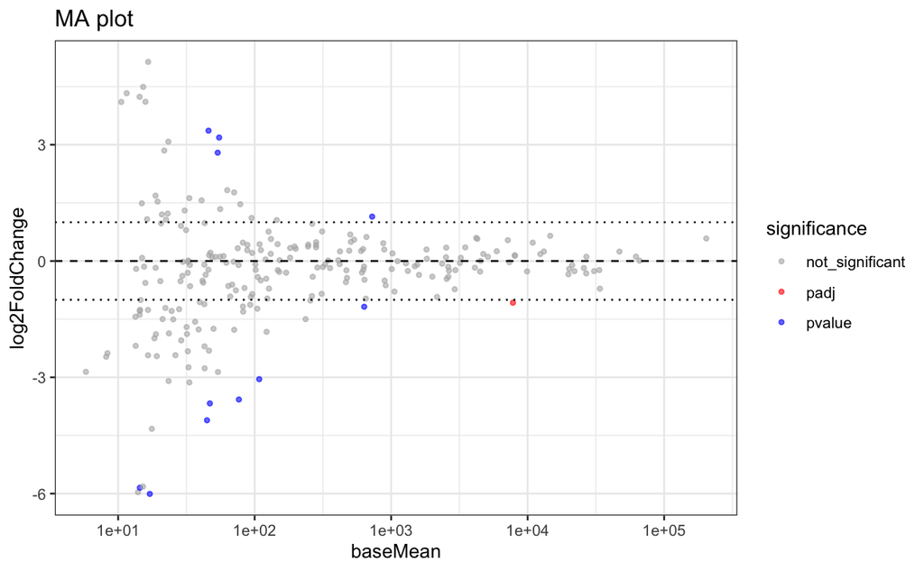

**Значимые результаты**

```
out of 243 with nonzero total read count
adjusted p-value < 0.05
LFC > 0 (up)       : 0, 0%
LFC < 0 (down)     : 1, 0.41%
outliers [1]       : 0, 0%
low counts [2]     : 0, 0%
(mean count < 6)
[1] see 'cooksCutoff' argument of ?results
[2] see 'independentFiltering' argument of ?results
```

|  | baseMean | log2FoldChange | lfcSE | stat | pvalue | padj |
| --- | --- | --- | --- | --- | --- | --- |
| hsa-miR-126-3p | 7804.162 | -1.075845 | 0.2896533 | -3.71425 | 0.0002038076 | 0.04952525 |

[figure not shown]

**Volcano plot**

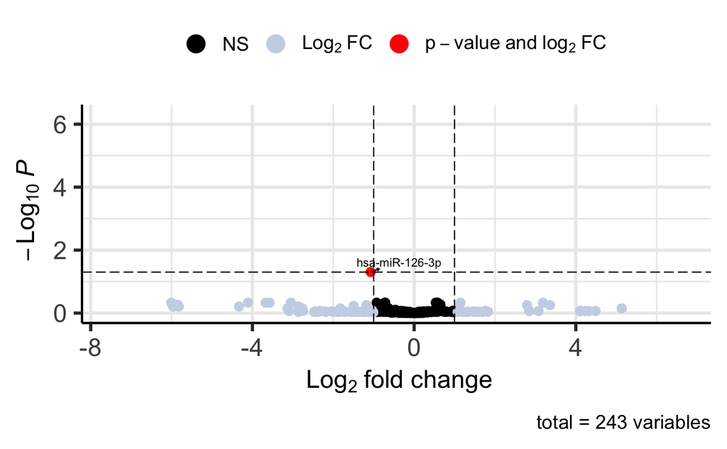

**rlog трансформация**

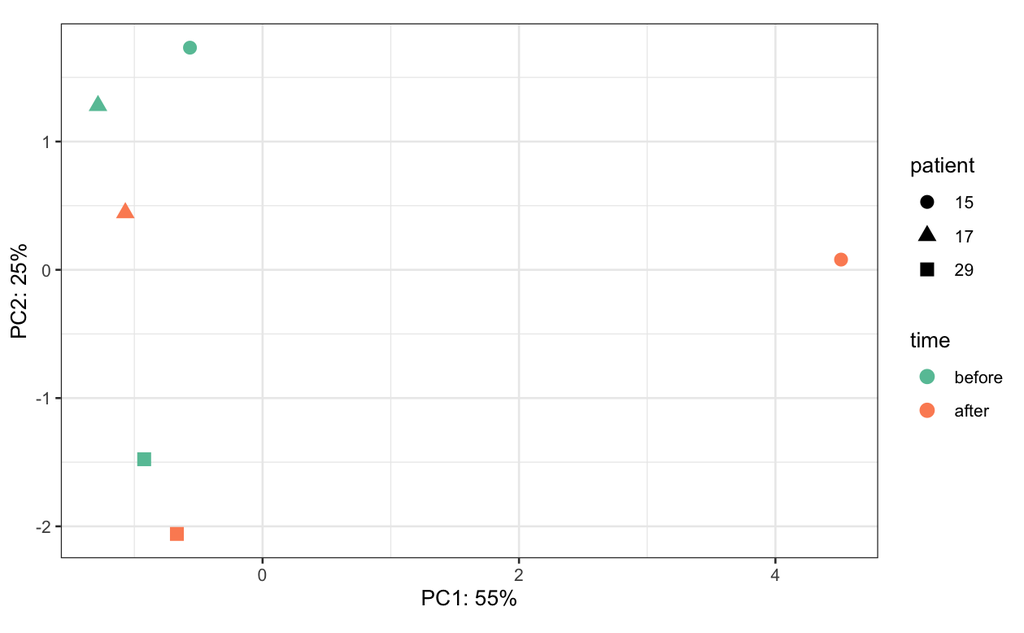

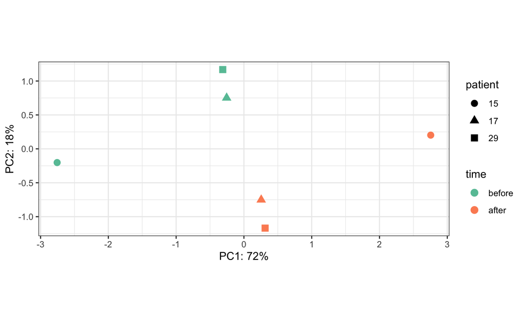

### Анализ обогащения для везикул типа 16

```
Searching mirecords ...
Searching mirtarbase ...
Searching tarbase ...
$down
character(0)

$up
```

| target_symbol |
| --- |
| VCAM1 |
| PIK3R2 |
| CRKL |
| IRS1 |
| VEGFA |
| TOM1 |
| CXCL12 |
| BCL2 |
| E2F1 |
| KRAS |

[output cut: 990 more lines]

```
NA
```

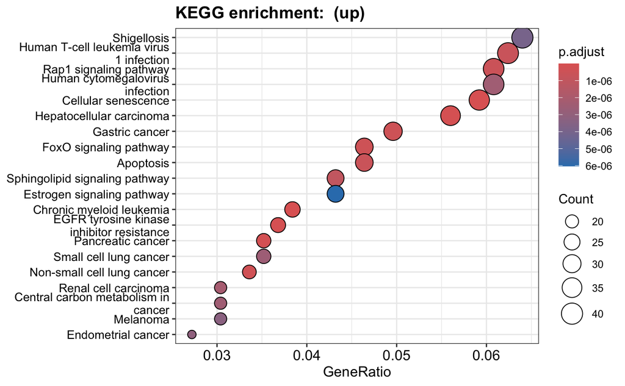

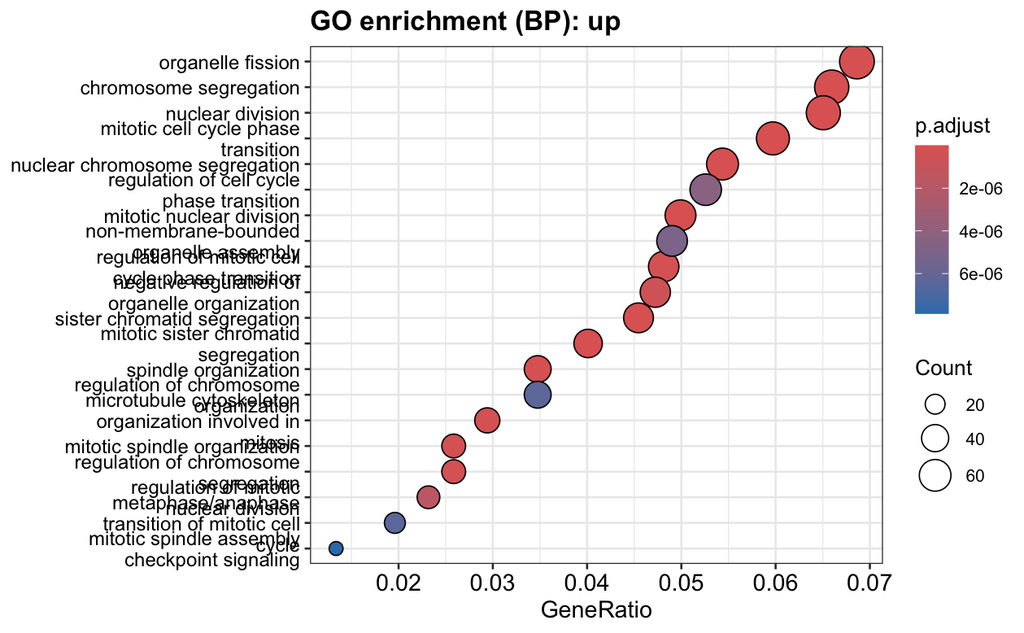